# Одна прямая: CSSA и классические фильтры

Alex

2026-03-13

## Вспомогательные функции

```r
clip01 <- function(m) {
  m <- as.matrix(m)
  m[!is.finite(m)] <- 0
  m[m < 0.001] <- 0
  m[m > 0.99] <- 1
  m
}

normalize_xtab <- function(tab) {
  t(apply(tab, 1, function(x) {
    row_min <- min(x, na.rm = TRUE)
    if (!is.finite(row_min)) {
      return(rep(NA_real_, length(x)))
    }
    if (row_min == 0) {
      ifelse(x == 0, 1, Inf)
    } else {
      x / row_min
    }
  }))
}

make_line_image <- function(n_row, n_col, a, b, intensity = 1) {
  matrix(0, nrow = n_row, ncol = n_col) |>
    add.line(a = a, b = b, intensity = intensity)
}

binary_by_quantile <- function(m, q = 0.9, use_abs = FALSE) {
  x <- as.matrix(m)
  x[!is.finite(x)] <- 0
  score <- if (use_abs) abs(x) else x
  thr <- as.numeric(stats::quantile(score, probs = q, na.rm = TRUE))
  out <- ifelse(score >= thr, clip01(x), 0)
  clip01(out)
}

cssa_denoise <- function(m, num_of_lines = 1L, method = "row.row") {
  cleaned <- switch(
    method,
    "col.col" = m |> dft() |> cssa.col(num.line = num_of_lines) |> idft.col() |> Re(),
    "col.row" = m |> dft() |> cssa.col(num.line = num_of_lines) |> idft.row() |> Re(),
    "row.col" = m |> dft() |> cssa.row(num.line = num_of_lines) |> idft.col() |> Re(),
    "row.row" = m |> dft() |> cssa.row(num.line = num_of_lines) |> idft.row() |> Re(),
    stop("Неизвестный CSSA-метод: ", method)
  )
  clip01(cleaned)
}

bm3d_denoise <- function(m, sigma_noise) {
  if (!bm3d_available) {
    stop("Python-модуль 'bm3d' недоступен.")
  }
  x <- as.matrix(m)
  x[!is.finite(x)] <- 0
  clip01(bm3d_lib$bm3d(x, sigma_psd = as.numeric(sigma_noise)))
}

median_denoise <- function(m, n = 3L) {
  clip01(as.matrix(imager::medianblur(imager::as.cimg(clip01(m)), n = as.integer(n))))
}

wiener_denoise <- function(m, ksize = 5L) {
  x <- clip01(m)
  ksize <- as.integer(ksize)
  if (ksize %% 2L == 0L) {
    ksize <- ksize + 1L
  }

  kernel <- matrix(1 / (ksize * ksize), nrow = ksize, ncol = ksize)
  local_mean <- EBImage::filter2(x, kernel, boundary = "replicate")
  local_var <- EBImage::filter2(x^2, kernel, boundary = "replicate") - local_mean^2
  local_var[local_var < 0] <- 0
  noise_var <- mean(local_var, na.rm = TRUE)

  gain <- pmax(local_var - noise_var, 0) / pmax(local_var, 1e-8)
  out <- local_mean + gain * (x - local_mean)
  clip01(out)
}

quantile_denoise <- function(m, q = 0.9) {
  x <- clip01(m)
  thr <- as.numeric(stats::quantile(x, probs = q, na.rm = TRUE))
  clip01(ifelse(x >= thr, x, 0))
}

convert_ab_to_rho_theta <- function(a, b) {
  theta <- atan2(1, -a)
  rho <- b / sqrt(a^2 + 1)
  if (theta < 0) {
    theta <- theta + pi
    rho <- -rho
  }
  c(rho = rho, theta = theta)
}

find_k_max <- function(acc, k, qrho, qtheta, suppress = FALSE, window = 6L) {
  acc_copy <- acc
  maxima <- vector("list", k)

  for (i in seq_len(k)) {
    idx <- which(acc_copy == max(acc_copy), arr.ind = TRUE)[1, ]
    maxima[[i]] <- c(rho = qrho[idx[1]], theta = qtheta[idx[2]])

    if (suppress) {
      r_range <- max(1, idx[1] - window):min(nrow(acc_copy), idx[1] + window)
      c_range <- max(1, idx[2] - window):min(ncol(acc_copy), idx[2] + window)
      acc_copy[r_range, c_range] <- 0
    } else {
      acc_copy[idx[1], idx[2]] <- 0
    }
  }

  out <- do.call(rbind, maxima)
  colnames(out) <- c("rho", "theta")
  out
}

compute_err <- function(true, pred) {
  true <- as.matrix(true)
  pred <- as.matrix(pred)

  if (ncol(true) != 2 || ncol(pred) != 2) {
    stop("true и pred должны иметь по два столбца: rho и theta")
  }

  if (nrow(true) != nrow(pred)) {
    stop("true и pred должны содержать одинаковое число прямых")
  }

  pair_err <- function(tr, tt, pr, pt) {
    pt_alt <- (pt + pi) %% (2 * pi)
    dtheta <- atan2(sin(tt - pt), cos(tt - pt))^2
    dtheta_alt <- atan2(sin(tt - pt_alt), cos(tt - pt_alt))^2

    loss_1 <- (tr - pr)^2 + dtheta
    loss_2 <- (tr + pr)^2 + dtheta_alt

    if (loss_1 <= loss_2) {
      c(dr = (tr - pr)^2, dtheta = dtheta, total = loss_1)
    } else {
      c(dr = (tr + pr)^2, dtheta = dtheta_alt, total = loss_2)
    }
  }

  if (nrow(true) == 1) {
    out <- pair_err(true[1, 1], true[1, 2], pred[1, 1], pred[1, 2])
    return(c(dr = unname(out[1]), dtheta = unname(out[2])))
  }

  stop("В этом отчёте ожидается только одна прямая.")
}

summarise_ht_errors <- function(ht_error_samples) {
  ht_error_samples |>
    dplyr::group_by(config_id, description, method) |>
    dplyr::summarise(
      mean_dr = mean(dr),
      median_dr = median(dr),
      mean_dtheta = mean(dtheta),
      median_dtheta = median(dtheta),
      .groups = "drop"
    ) |>
    dplyr::arrange(config_id, mean_dr, mean_dtheta)
}

make_large_dr_meta <- function(large_dr_cases) {
  if (length(large_dr_cases) == 0) {
    return(data.frame(
      case_id = character(0),
      config_id = character(0),
      description = character(0),
      method = character(0),
      rep = integer(0),
      dr = numeric(0),
      dtheta = numeric(0),
      stringsAsFactors = FALSE
    ))
  }

  names(large_dr_cases) <- vapply(large_dr_cases, `[[`, character(1), "case_id")

  dplyr::bind_rows(lapply(large_dr_cases, function(x) {
    data.frame(
      case_id = x$case_id,
      config_id = x$config_id,
      description = x$description,
      method = x$method,
      rep = x$rep,
      dr = x$dr,
      dtheta = x$dtheta,
      stringsAsFactors = FALSE
    )
  }))
}

run_ht_experiment <- function(
  configs,
  detectors,
  sigma_noise,
  num_of_lines,
  rho_step_ht,
  theta_step_ht,
  n_rep,
  n_repeats_large_dr,
  large_dr_method,
  large_dr_max_cases,
  dr_large_threshold
) {
  results_list <- vector("list", length = nrow(configs) * n_rep * length(detectors))
  large_dr_cases <- list()
  idx_out <- 1L

  for (cfg_i in seq_len(nrow(configs))) {
    cfg <- configs[cfg_i, ]
    base_matrix <- make_line_image(
      n_row = cfg$n_row,
      n_col = cfg$n_col,
      a = cfg$a,
      b = cfg$b
    )
    true_line <- matrix(convert_ab_to_rho_theta(cfg$a, cfg$b), nrow = 1)

    for (rep_i in seq_len(n_rep)) {
      noisy_matrix <- add.noise(base_matrix, sigma = sigma_noise)

      for (method_name in names(detectors)) {
        processed_matrix <- clip01(detectors[[method_name]](
          noisy_matrix,
          sigma_noise = sigma_noise
        ))

        ht_result <- make_accumulator(
          noisy_matrix,
          detector = function(m) processed_matrix,
          rho_step = rho_step_ht,
          theta_step = theta_step_ht
        )

        pred_line <- find_k_max(
          ht_result$accumulator,
          k = num_of_lines,
          qrho = ht_result$rho,
          qtheta = ht_result$theta,
          suppress = FALSE,
          window = 0L
        )

        err <- compute_err(true_line, pred_line)

        results_list[[idx_out]] <- data.frame(
          config_id = cfg$config_id,
          description = cfg$description,
          n_col = cfg$n_col,
          n_row = cfg$n_row,
          a = cfg$a,
          b = cfg$b,
          sigma = sigma_noise,
          rep = rep_i,
          method = method_name,
          true_rho = true_line[1, 1],
          true_theta = true_line[1, 2],
          pred_rho = pred_line[1, 1],
          pred_theta = pred_line[1, 2],
          active_pixels = sum(processed_matrix > 0),
          dr = as.numeric(err["dr"]),
          dtheta = as.numeric(err["dtheta"]),
          stringsAsFactors = FALSE
        )

        idx_out <- idx_out + 1L
      }
    }
  }

  for (cfg_i in seq_len(nrow(configs))) {
    if (length(large_dr_cases) >= large_dr_max_cases) {
      break
    }

    cfg <- configs[cfg_i, ]
    base_matrix <- make_line_image(
      n_row = cfg$n_row,
      n_col = cfg$n_col,
      a = cfg$a,
      b = cfg$b
    )
    true_line <- matrix(convert_ab_to_rho_theta(cfg$a, cfg$b), nrow = 1)

    for (rep_i in seq_len(n_repeats_large_dr)) {
      if (length(large_dr_cases) >= large_dr_max_cases) {
        break
      }

      noisy_matrix <- add.noise(base_matrix, sigma = sigma_noise)
      processed_matrix <- clip01(detectors[[large_dr_method]](
        noisy_matrix,
        sigma_noise = sigma_noise
      ))

      ht_result <- make_accumulator(
        noisy_matrix,
        detector = function(m) processed_matrix,
        rho_step = rho_step_ht,
        theta_step = theta_step_ht
      )

      pred_line <- find_k_max(
        ht_result$accumulator,
        k = num_of_lines,
        qrho = ht_result$rho,
        qtheta = ht_result$theta,
        suppress = FALSE,
        window = 0L
      )

      err <- compute_err(true_line, pred_line)

      if (is.finite(err["dr"]) && err["dr"] > dr_large_threshold) {
        large_dr_cases[[length(large_dr_cases) + 1L]] <- list(
          case_id = sprintf("%s__%s__rep_%03d", cfg$config_id, large_dr_method, rep_i),
          config_id = cfg$config_id,
          description = cfg$description,
          method = large_dr_method,
          rep = rep_i,
          dr = as.numeric(err["dr"]),
          dtheta = as.numeric(err["dtheta"]),
          noisy_matrix = noisy_matrix,
          processed_matrix = processed_matrix
        )
      }
    }
  }

  list(
    ht_error_samples = do.call(rbind, results_list),
    large_dr_cases = large_dr_cases
  )
}
```

Параметры эксперимента. В частности, $\sigma=0.2$, 1 прямая, параметры дискретизации аккумуляторного массива и тп.

```r
sigma_noise <- 0.2
num_of_lines <- 1
detector_q <- 0.9
rho_step_ht <- 1
theta_step_ht <- 0.01
dr_large_threshold <- 8000
n_rep <- 100L
n_repeats_large_dr <- 100L
large_dr_method <- "cssa_row_row"
large_dr_max_cases <- 10L

configs <- data.frame(
  config_id = c(
    "diag_pos_full",
    "diag_neg_full",
    "steep_full",
    "steep_shifted"
  ),
  n_col = rep(100L, 4),
  n_row = rep(100L, 4),
  a = c(1, -1, 2, 2),
  b = c(0, 101, -1, -40),
  description = c(
    "Positive full diagonal",
    "Negative full diagonal",
    "Steep line crossing most of the image",
    "Steep shifted line with shorter visible segment"
  ),
  stringsAsFactors = FALSE
)

configs
```

```
##       config_id n_col n_row  a   b
## 1 diag_pos_full   100   100  1   0
## 2 diag_neg_full   100   100 -1 101
## 3    steep_full   100   100  2  -1
## 4 steep_shifted   100   100  2 -40
##                                       description
## 1                          Positive full diagonal
## 2                          Negative full diagonal
## 3           Steep line crossing most of the image
## 4 Steep shifted line with shorter visible segment
```

Вот так выглядят эти прямые.

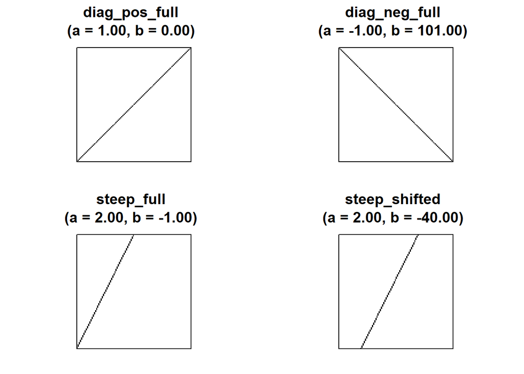

```r
config_images <- lapply(seq_len(nrow(configs)), function(i) {
  make_line_image(
    n_row = configs$n_row[i],
    n_col = configs$n_col[i],
    a = configs$a[i],
    b = configs$b[i]
  )
})

config_labels <- sprintf(
  "%s\n(a = %.2f, b = %.2f)",
  configs$config_id,
  configs$a,
  configs$b
)

plot.matrix(
  config_images,
  from.0.to.1 = TRUE,
  labels = config_labels,
  nplots = 2
)
```

## Далее будут идти результаты работы разных предобработок.

`ROW-ROW`

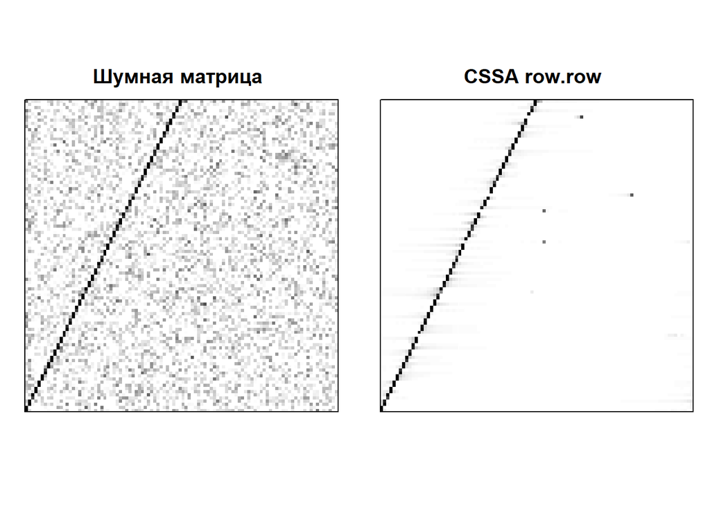

```r
demo_matrix <- make_line_image(100, 100, a = 2, b = -1)
demo_noisy <- add.noise(demo_matrix, sigma = sigma_noise)
demo_cssa <- cssa_denoise(
  demo_noisy,
  num_of_lines = num_of_lines,
  method = "row.row"
)

plot.matrix(
  list(
    "Шумная матрица" = clip01(demo_noisy),
    "CSSA row.row" = demo_cssa
  ),
  from.0.to.1 = TRUE,
  labels = c("Шумная матрица", "CSSA row.row"),
  nplots = 2
)
```

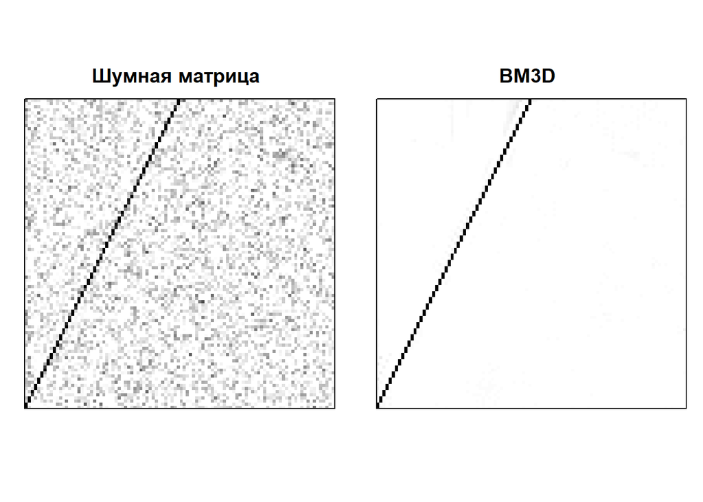

```r
if (bm3d_available) {
  demo_bm3d <- bm3d_denoise(demo_noisy, sigma_noise = sigma_noise)

  plot.matrix(
    list(
      "Шумная матрица" = clip01(demo_noisy),
      "BM3D" = demo_bm3d
    ),
    from.0.to.1 = TRUE,
    labels = c("Шумная матрица", "BM3D"),
    nplots = 2
  )
} else {
  cat("BM3D пропущен: Python-модуль 'bm3d' не найден в текущем окружении.\n")
}
```

`Медианный фильтр`.

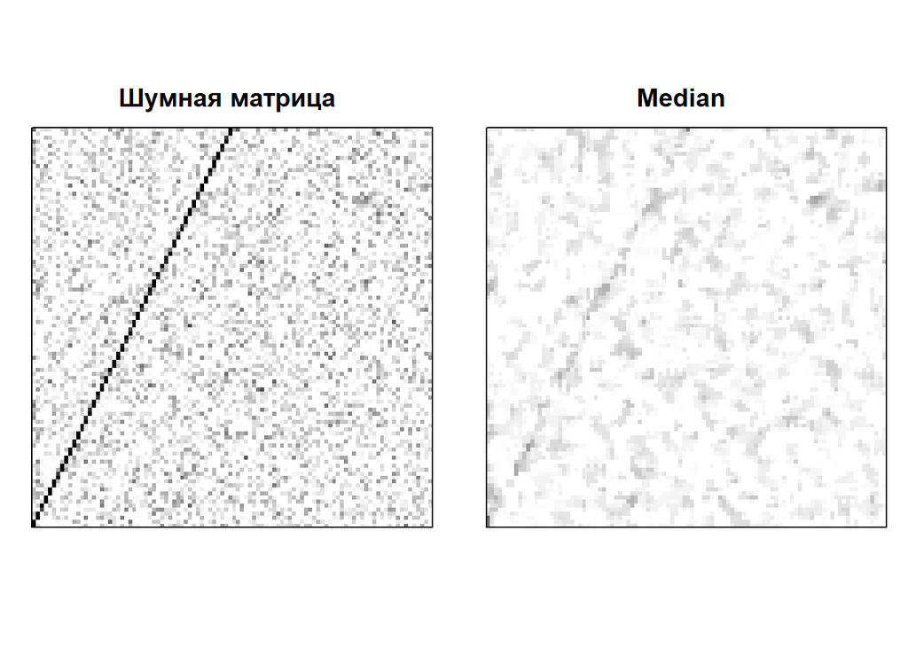

```r
demo_median <- median_denoise(demo_noisy, n = 3L)

plot.matrix(
  list(
    "Шумная матрица" = clip01(demo_noisy),
    "Median" = demo_median
  ),
  from.0.to.1 = TRUE,
  labels = c("Шумная матрица", "Median"),
  nplots = 2
)
```

`Фильтр Винера`.

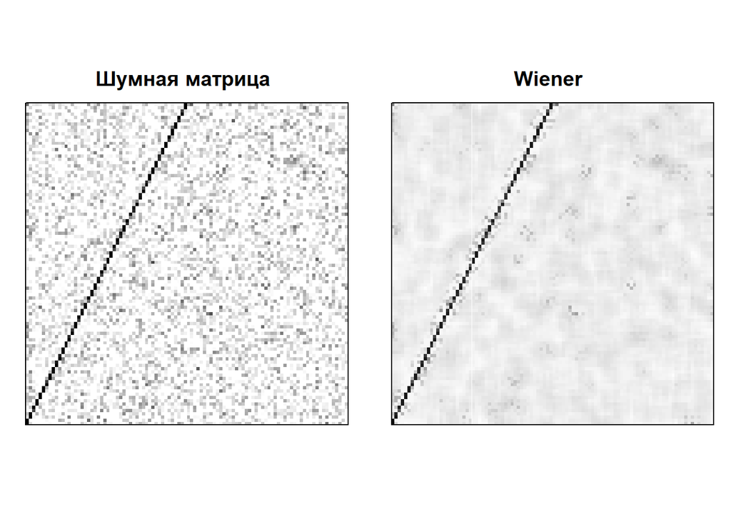

```r
demo_wiener <- wiener_denoise(demo_noisy, ksize = 5L)

plot.matrix(
  list(
    "Шумная матрица" = clip01(demo_noisy),
    "Wiener" = demo_wiener
  ),
  from.0.to.1 = TRUE,
  labels = c("Шумная матрица", "Wiener"),
  nplots = 2
)
```

`Квантильный Фильтр`.

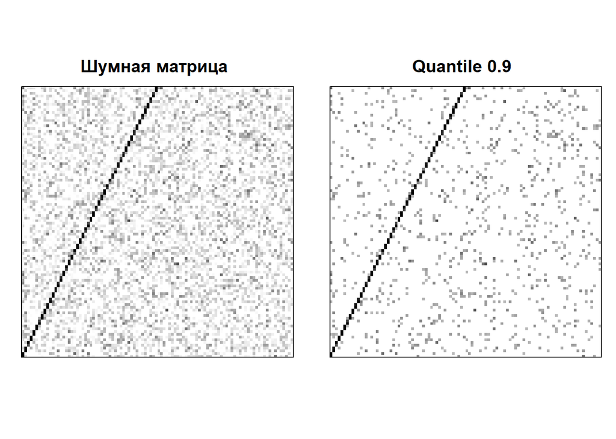

```r
demo_quantile <- quantile_denoise(demo_noisy, q = detector_q)

plot.matrix(
  list(
    "Шумная матрица" = clip01(demo_noisy),
    "Quantile 0.9" = demo_quantile
  ),
  from.0.to.1 = TRUE,
  labels = c("Шумная матрица", "Quantile 0.9"),
  nplots = 2
)
```

```r
detectors <- list(
  cssa_row_row = function(m, sigma_noise) {
    cssa_denoise(m, num_of_lines = num_of_lines, method = "row.row")
  },
  median = function(m, sigma_noise) {
    median_denoise(m, n = 3L)
  },
  wiener = function(m, sigma_noise) {
    wiener_denoise(m, ksize = 5L)
  },
  quantile_09 = function(m, sigma_noise) {
    quantile_denoise(m, q = detector_q)
  }
)

if (bm3d_available) {
  detectors <- append(
    detectors,
    list(
      bm3d = function(m, sigma_noise) {
        bm3d_denoise(m, sigma_noise = sigma_noise)
      }
    ),
    after = 1L
  )
}

names(detectors)
```

```
## [1] "cssa_row_row" "bm3d"         "median"       "wiener"       "quantile_09"
```

## Эксперимент

```r
main_experiment <- run_ht_experiment(
  configs = configs,
  detectors = detectors,
  sigma_noise = sigma_noise,
  num_of_lines = num_of_lines,
  rho_step_ht = rho_step_ht,
  theta_step_ht = theta_step_ht,
  n_rep = n_rep,
  n_repeats_large_dr = n_repeats_large_dr,
  large_dr_method = large_dr_method,
  large_dr_max_cases = large_dr_max_cases,
  dr_large_threshold = dr_large_threshold
)

ht_error_samples <- main_experiment$ht_error_samples
large_dr_cases <- main_experiment$large_dr_cases

head(ht_error_samples, 12)
```

```
##           config_id            description n_col n_row a b sigma rep
## rho   diag_pos_full Positive full diagonal   100   100 1 0   0.2   1
## rho1  diag_pos_full Positive full diagonal   100   100 1 0   0.2   1
## rho2  diag_pos_full Positive full diagonal   100   100 1 0   0.2   1
## rho3  diag_pos_full Positive full diagonal   100   100 1 0   0.2   1
## rho4  diag_pos_full Positive full diagonal   100   100 1 0   0.2   1
## rho5  diag_pos_full Positive full diagonal   100   100 1 0   0.2   2
## rho6  diag_pos_full Positive full diagonal   100   100 1 0   0.2   2
## rho7  diag_pos_full Positive full diagonal   100   100 1 0   0.2   2
## rho8  diag_pos_full Positive full diagonal   100   100 1 0   0.2   2
## rho9  diag_pos_full Positive full diagonal   100   100 1 0   0.2   2
## rho10 diag_pos_full Positive full diagonal   100   100 1 0   0.2   3
## rho11 diag_pos_full Positive full diagonal   100   100 1 0   0.2   3
##             method true_rho true_theta pred_rho pred_theta active_pixels dr
## rho   cssa_row_row        0   2.356194        0       2.36          3871  0
## rho1          bm3d        0   2.356194        0       2.35          4436  0
## rho2        median        0   2.356194        0       2.36          5022  0
## rho3        wiener        0   2.356194        0       2.36          9999  0
## rho4   quantile_09        0   2.356194        0       2.36          1000  0
## rho5  cssa_row_row        0   2.356194        0       2.36          3780  0
## rho6          bm3d        0   2.356194        0       2.36          3819  0
## rho7        median        0   2.356194        0       2.36          5004  0
## rho8        wiener        0   2.356194        0       2.36         10000  0
## rho9   quantile_09        0   2.356194        0       2.36          1000  0
## rho10 cssa_row_row        0   2.356194        0       2.36          3717  0
## rho11         bm3d        0   2.356194        0       2.36          4389  0
##             dtheta
## rho   1.448190e-05
## rho1  3.837171e-05
## rho2  1.448190e-05
## rho3  1.448190e-05
## rho4  1.448190e-05
## rho5  1.448190e-05
## rho6  1.448190e-05
## rho7  1.448190e-05
## rho8  1.448190e-05
## rho9  1.448190e-05
## rho10 1.448190e-05
## rho11 1.448190e-05
```

## Об ошибке steep_full

Смотрим на аномальные матрицы, если они есть

```r
large_dr_meta
```

```
##                              case_id  config_id
## 1  steep_full__cssa_row_row__rep_001 steep_full
## 2  steep_full__cssa_row_row__rep_012 steep_full
## 3  steep_full__cssa_row_row__rep_034 steep_full
## 4  steep_full__cssa_row_row__rep_054 steep_full
## 5  steep_full__cssa_row_row__rep_063 steep_full
## 6  steep_full__cssa_row_row__rep_065 steep_full
## 7  steep_full__cssa_row_row__rep_068 steep_full
## 8  steep_full__cssa_row_row__rep_077 steep_full
## 9  steep_full__cssa_row_row__rep_085 steep_full
## 10 steep_full__cssa_row_row__rep_088 steep_full
##                              description       method rep       dr  dtheta
## 1  Steep line crossing most of the image cssa_row_row   1 9130.335 4.09515
## 2  Steep line crossing most of the image cssa_row_row  12 9322.441 4.09515
## 3  Steep line crossing most of the image cssa_row_row  34 8940.229 4.09515
## 4  Steep line crossing most of the image cssa_row_row  54 9712.652 4.09515
## 5  Steep line crossing most of the image cssa_row_row  63 8019.702 4.09515
## 6  Steep line crossing most of the image cssa_row_row  65 8381.913 4.09515
## 7  Steep line crossing most of the image cssa_row_row  68 8199.807 4.09515
## 8  Steep line crossing most of the image cssa_row_row  77 8940.229 4.09515
## 9  Steep line crossing most of the image cssa_row_row  85 8199.807 4.09515
## 10 Steep line crossing most of the image cssa_row_row  88 8019.702 4.09515
```

```r
if (nrow(large_dr_meta) > 0) {
  xtabs(~ config_id + method, data = large_dr_meta)
}
```

```
##             method
## config_id    cssa_row_row
##   steep_full           10
```

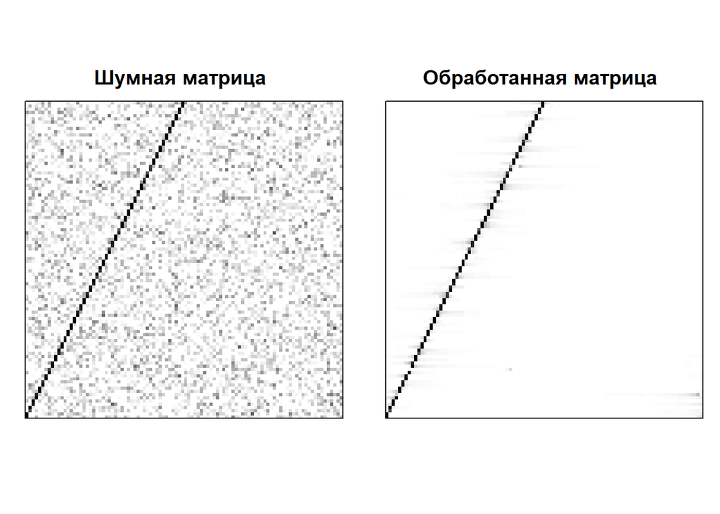

```r
if (length(large_dr_cases) > 0) {
  first_large_case <- large_dr_cases[[1]]

  plot.matrix(
    list(
      "Шумная матрица" = clip01(first_large_case$noisy_matrix),
      "Обработанная матрица" = first_large_case$processed_matrix
    ),
    from.0.to.1 = TRUE,
    labels = c("Шумная матрица", "Обработанная матрица"),
    nplots = 2
  )

}
```

Немного изменил find_k_max, чтобы вывести аккумуляторный массив на аномальных матрицах.

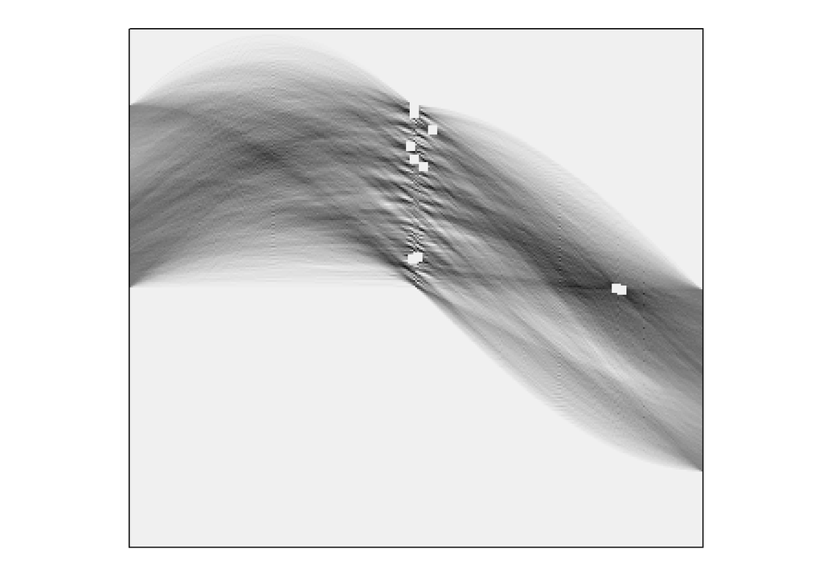

```
##       rho theta
##  [1,]  96  1.56
##  [2,]   0  2.67
##  [3,]  17  1.58
##  [4,]  78  1.54
##  [5,]  -1  2.70
##  [6,]  16  1.55
##  [7,]  67  1.61
##  [8,] 100  1.56
##  [9,]  87  1.66
## [10,]  71  1.56
```

```r
find_k_max_special <- function(acc, k, qrho, qtheta, suppress = FALSE, window = 6L) {
  acc_copy <- acc
  maxima <- vector("list", k)

  for (i in seq_len(k)) {
    idx <- which(acc_copy == max(acc_copy), arr.ind = TRUE)[1, ]
    maxima[[i]] <- c(rho = qrho[idx[1]], theta = qtheta[idx[2]])

    if (suppress) {
      r_range <- max(1, idx[1] - window):min(nrow(acc_copy), idx[1] + window)
      c_range <- max(1, idx[2] - window):min(ncol(acc_copy), idx[2] + window)
      acc_copy[r_range, c_range] <- 0
    } else {
      acc_copy[idx[1], idx[2]] <- 0
    }
  }

  out <- do.call(rbind, maxima)
  colnames(out) <- c("rho", "theta")
  print(plot.matrix(acc_copy))
  out
}


  first_large_case <- large_dr_cases[[1]]
  ht <- first_large_case$noisy_matrix |> make_accumulator(cssa_denoise,rho_step = 1, theta_step = 0.01)

  find_k_max_special(ht$accumulator, 10, ht$rho, ht$theta, T, 2)
```

```r
  convert_ab_to_rho_theta(2, -1)
```

```
##        rho      theta
## -0.4472136  2.6779450
```

Мы видим, что большая часть лок максимумов находится на уровне $\theta=\pi/2$. Значит, остается много пикселей, которые воспринимаются алгоритмом как часть горизонтальной прямой. Таким образом, k локальных максимумов в аккумуляторном массиве – это k горизонтальных прямых, с разницей в смещении.

А теперь посмотрим на результат row.row, только бинаризуем все, чтобы от интенсивности не зависело:

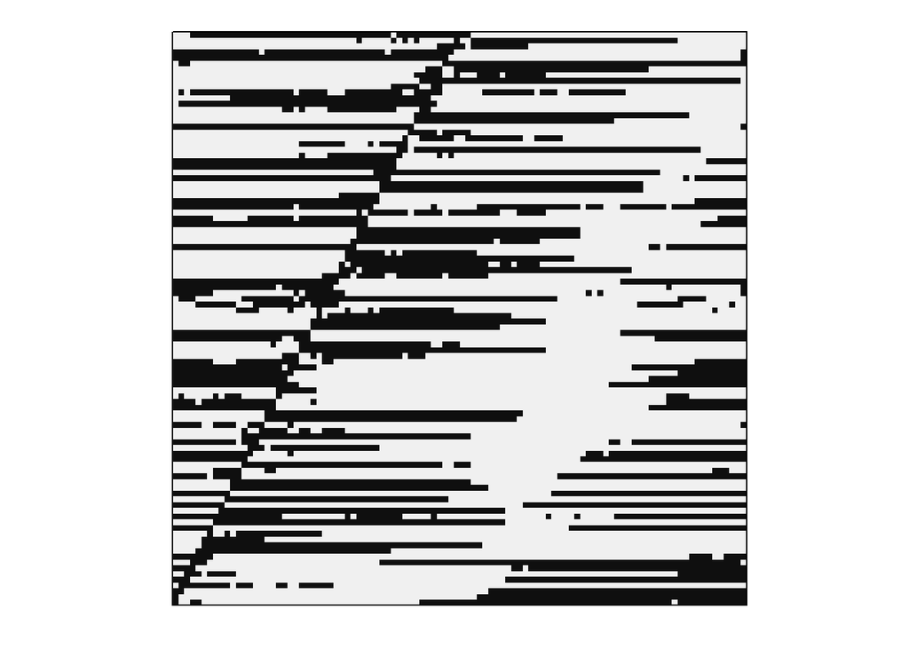

```r
x <- first_large_case$noisy_matrix |> cssa_denoise()
x <- ifelse(x > 0, 1, 0)
x |> plot.matrix()
```

И, так как преобразование Хафа не обращает внимание на интенсивность, то голосование происходит за несколько горизонтальных прямых прежде, чем дойти до искомой прямой. Для сравнения, квантильный фильтр дает такой результат:

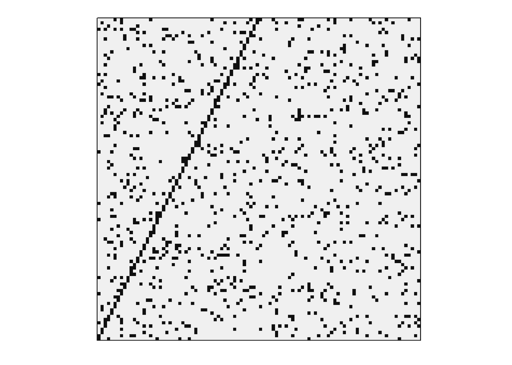

```r
x <- first_large_case$noisy_matrix |> quantile_denoise()
x <- ifelse(x > 0, 1, 0)
x |> plot.matrix()
```

## Результаты

Агрегированная сводка по средним и медианам ошибок Хафа.

```r
ht_error_summary <- summarise_ht_errors(ht_error_samples)

ht_error_summary
```

```
## # A tibble: 20 × 7
##    config_id     description  method mean_dr median_dr mean_dtheta median_dtheta
##    <chr>         <chr>        <chr>    <dbl>     <dbl>       <dbl>         <dbl>
##  1 diag_neg_full Negative fu… quant… 1.75e-1    0.175   0.0000227     0.0000212
##  2 diag_neg_full Negative fu… cssa_… 2.06e-1    0.175   0.0000457     0.0000212
##  3 diag_neg_full Negative fu… median 2.14e-1    0.175   0.0000316     0.0000212
##  4 diag_neg_full Negative fu… bm3d   7.44e+1    0.339   0.0375        0.0000291
##  5 diag_neg_full Negative fu… wiener 5.10e+3 5100.      2.46          2.46
##  6 diag_pos_full Positive fu… cssa_… 0          0       0.0000145     0.0000145
##  7 diag_pos_full Positive fu… median 0          0       0.0000145     0.0000145
##  8 diag_pos_full Positive fu… quant… 0          0       0.0000145     0.0000145
##  9 diag_pos_full Positive fu… wiener 0          0       0.0000145     0.0000145
## 10 diag_pos_full Positive fu… bm3d   2.33e+0    0       0.0000641     0.0000145
## 11 steep_full    Steep line … quant… 2   e-1    0.2     0.0000631     0.0000631
## 12 steep_full    Steep line … wiener 2   e-1    0.2     0.101         0.101
## 13 steep_full    Steep line … median 1.02e+2    0.306   0.0360        0.00000422
## 14 steep_full    Steep line … bm3d   6.22e+2    0.306   0.386         0.000145
## 15 steep_full    Steep line … cssa_… 1.83e+3   12.6     2.21          3.97
## 16 steep_shifted Steep shift… cssa_… 1.24e-2    0.0124  0.00000422    0.00000422
## 17 steep_shifted Steep shift… quant… 1.24e-2    0.0124  0.00000422    0.00000422
## 18 steep_shifted Steep shift… median 6.60e+1    0.0124  0.0304        0.00000422
## 19 steep_shifted Steep shift… bm3d   7.01e+1    0.0124  0.252         0.00000422
## 20 steep_shifted Steep shift… wiener 3.20e+2  320       0.101         0.101
```

Таблицы средних значений `dr` и их нормированные версии.

```r
mean_dr_table <- xtabs(mean_dr ~ config_id + method, data = ht_error_summary)
mean_dr_table
```

```
##                method
## config_id               bm3d cssa_row_row       median  quantile_09
##   diag_neg_full 7.443233e+01 2.057860e-01 2.140075e-01 1.745442e-01
##   diag_pos_full 2.330000e+00 0.000000e+00 0.000000e+00 0.000000e+00
##   steep_full    6.219409e+02 1.829924e+03 1.019407e+02 2.000000e-01
##   steep_shifted 7.008796e+01 1.242248e-02 6.596654e+01 1.242248e-02
##                method
## config_id             wiener
##   diag_neg_full 5.100500e+03
##   diag_pos_full 0.000000e+00
##   steep_full    2.000000e-01
##   steep_shifted 3.200000e+02
```

```r
mean_dr_table_norm <- normalize_xtab(mean_dr_table)
mean_dr_table_norm
```

```
##                method
## config_id            bm3d cssa_row_row      median quantile_09   wiener
##   diag_neg_full  426.4382      1.17899    1.226093           1 29221.82
##   diag_pos_full       Inf      1.00000    1.000000           1     1.00
##   steep_full    3109.7047   9149.61860  509.703530           1     1.00
##   steep_shifted 5642.0267      1.00000 5310.255460           1 25759.75
```

Видим, что `row.row` как предобработка выдает хорошие показатели: за исключением квантильного фильтра эта предобработка имеет меньшие показатели везде, кроме steep_full.

Аналогично с медианами

```r
median_dr_table <- xtabs(median_dr ~ config_id + method, data = ht_error_summary)
median_dr_table
```

```
##                method
## config_id               bm3d cssa_row_row       median  quantile_09
##   diag_neg_full 3.389744e-01 1.745442e-01 1.745442e-01 1.745442e-01
##   diag_pos_full 0.000000e+00 0.000000e+00 0.000000e+00 0.000000e+00
##   steep_full    3.055728e-01 1.262229e+01 3.055728e-01 2.000000e-01
##   steep_shifted 1.242248e-02 1.242248e-02 1.242248e-02 1.242248e-02
##                method
## config_id             wiener
##   diag_neg_full 5.100500e+03
##   diag_pos_full 0.000000e+00
##   steep_full    2.000000e-01
##   steep_shifted 3.200000e+02
```

```r
median_dr_table_norm <- normalize_xtab(median_dr_table)
median_dr_table_norm
```

```
##                method
## config_id           bm3d cssa_row_row   median quantile_09   wiener
##   diag_neg_full 1.942055      1.00000 1.000000           1 29221.82
##   diag_pos_full 1.000000      1.00000 1.000000           1     1.00
##   steep_full    1.527864     63.11146 1.527864           1     1.00
##   steep_shifted 1.000000      1.00000 1.000000           1 25759.75
```

По $\theta$

```r
mean_dtheta_table <- xtabs(mean_dtheta ~ config_id + method, data = ht_error_summary)
mean_dtheta_table
```

```
##                method
## config_id               bm3d cssa_row_row       median  quantile_09
##   diag_neg_full 3.748338e-02 4.572515e-05 3.156588e-05 2.268992e-05
##   diag_pos_full 6.406538e-05 1.448190e-05 1.448190e-05 1.448190e-05
##   steep_full    3.862628e-01 2.205234e+00 3.601606e-02 6.312373e-05
##   steep_shifted 2.521018e-01 4.222842e-06 3.044987e-02 4.222842e-06
##                method
## config_id             wiener
##   diag_neg_full 2.455460e+00
##   diag_pos_full 1.448190e-05
##   steep_full    1.010891e-01
##   steep_shifted 1.010891e-01
```

```r
mean_dtheta_table_norm <- normalize_xtab(mean_dtheta_table)
mean_dtheta_table_norm
```

```
##                method
## config_id               bm3d cssa_row_row      median quantile_09     wiener
##   diag_neg_full  1651.983529     2.015218    1.391185           1 108218.103
##   diag_pos_full     4.423822     1.000000    1.000000           1      1.000
##   steep_full     6119.137976 34935.101430  570.562940           1   1601.443
##   steep_shifted 59699.572232     1.000000 7210.752549           1  23938.631
```

Медианные ошибки по $\theta$

```r
median_dtheta_table <- xtabs(median_dtheta ~ config_id + method, data = ht_error_summary)
median_dtheta_table
```

```
##                method
## config_id               bm3d cssa_row_row       median  quantile_09
##   diag_neg_full 2.914017e-05 2.117690e-05 2.117690e-05 2.117690e-05
##   diag_pos_full 1.448190e-05 1.448190e-05 1.448190e-05 1.448190e-05
##   steep_full    1.453219e-04 3.974631e+00 4.222842e-06 6.312373e-05
##   steep_shifted 4.222842e-06 4.222842e-06 4.222842e-06 4.222842e-06
##                method
## config_id             wiener
##   diag_neg_full 2.455460e+00
##   diag_pos_full 1.448190e-05
##   steep_full    1.010891e-01
##   steep_shifted 1.010891e-01
```

```r
median_dtheta_table_norm <- normalize_xtab(median_dtheta_table)
median_dtheta_table_norm
```

```
##                method
## config_id            bm3d cssa_row_row median quantile_09    wiener
##   diag_neg_full  1.376036          1.0      1     1.00000 115949.94
##   diag_pos_full  1.000000          1.0      1     1.00000      1.00
##   steep_full    34.413307     941221.8      1    14.94816  23938.63
##   steep_shifted  1.000000          1.0      1     1.00000  23938.63
```